# 網頁解析 Parser

蔡芸琤

## 網頁架構及語法

- <標籤>內容</標籤>

  ```bash
  <html>
    <head>
    </head>
    <body>
      <h1> 標題 </h1>
      <p> 段落 </p>
      <ol>
          <li> 項目內容 1 </li>
          <li> 項目內容 2 </li>
      </ol>
    </body>
  </html>
  ```

## 複習影片: https://hiskio.com/course/48/lecture/125

## PTT電影版目錄列表

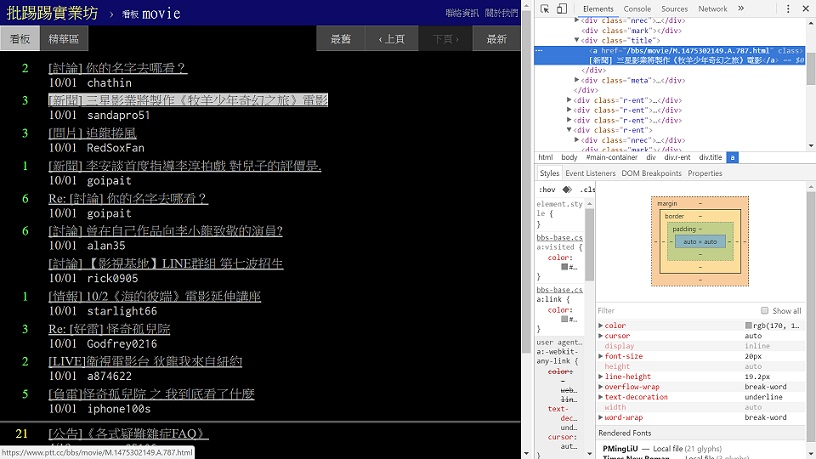

## XPath (1/3)

- XPath: Extensible Markup Language (XML) Path Language, XPath基於XML的巢狀結構，提供找尋節點的能力。
- XML v.s. HTML: HTML的各個標籤已被定義，所以，瀏覽器可直接解析。XML依使用者所需定義新標籤，所以，XML需要「剖析程式」(Parser)進行處理。
- XPath的用途: 將HTML檔當成字串集合，若轉成XML格式，可利用XML的Parser解析成巢狀結構，再由XPath取得節點中的內容。
- XPath常用的運算符

  ```bash
  "/" 選取根節點
  "//" 選取任何節點
  "@" 選取屬性(attribute)
  "*" 選取所有節點
  "|" OR
  ```

## XPath (2/3)

- 在瀏覽器chrome上安裝XPath Helper套件: https://chrome.google.com/webstore/detail/xpath-helper/hgimnogjllphhhkhlmebbmlgjoejdpjl

[figure not shown]

## XPath (3/3)

- 利用XPath運算符取得節點中的內容

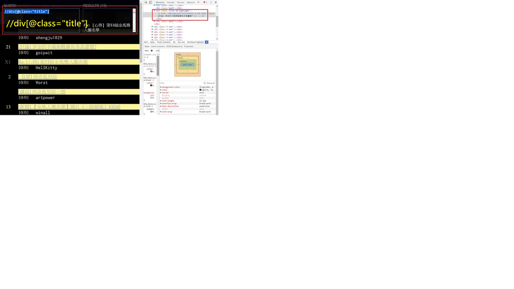

## 第一個爬蟲程式(Crawler) (1/3)

- 查詢語系設定

  ```bash
  > Sys.getlocale("LC_ALL")
  [1] "LC_COLLATE=English_United States.1252;
  LC_CTYPE=English_United States.1252;
  LC_MONETARY=English_United States.1252;
  LC_NUMERIC=C;LC_TIME=English_United States.1252"
  ```

- 更改語系為繁體中文

  ```bash
  > Sys.setlocale(category = "LC_ALL", locale = "cht")
  [1] "LC_COLLATE=Chinese (Traditional)_Taiwan.950;
  LC_CTYPE=Chinese (Traditional)_Taiwan.950;
  LC_MONETARY=Chinese (Traditional)_Taiwan.950;
  LC_NUMERIC=C;LC_TIME=Chinese (Traditional)_Taiwan.950"
  ```

## 第一個爬蟲程式(Crawler) (2/3)

- 安裝套件

  ```bash
  > install.packages("XML")
  > install.packages("RCurl")
  > install.packages("httr")
  ```

- 清空記憶體與載入套件

  ```bash
  rm(list=ls(all.names=TRUE))
  library(XML)
  library(RCurl)
  library(httr)
  ```

## 第一個爬蟲程式(Crawler) (3/3)

- 解析出文章中指定段落內容

  ```bash
  urlPath <- "https://www.ptt.cc/bbs/movie/index.html"
  temp    <- getURL(urlPath, encoding = "big5")
  xmldoc  <- htmlParse(temp)
  title   <- xpathSApply(xmldoc, "//div[@class=\"title\"]", xmlValue)
  ```

- 印出字串向量

  ```bash
  > title
   [1] "\n\t\t\t\n\t\t\t\t[討論] 你的名字去哪看？\n\t\t\t\n\t\t\t"
   [2] "\n\t\t\t\n\t\t\t\t[新聞] 三星影業將製作《牧羊少年奇幻之旅》電影\n\t"
   [3] "\n\t\t\t\n\t\t\t\t[問片] 追龍捲風\n\t\t\t\n\t\t\t"
   [4] "\n\t\t\t\n\t\t\t\t[新聞] 李安談首度指導李淳拍戲 對兒子的評價是.\n"
   [5] "\n\t\t\t\n\t\t\t\tRe: [討論] 你的名字去哪看？\n\t\t\t\n\t\t\t"
  ```

## 正規表示式Regular Expression (1/2)

- 正規表示式: 以單個字符串描述一系列符合某句法規則的字符串。
- 正規表示式列表: https://atedev.wordpress.com/2007/11/23/正規表示式-regular-expression/
- 使用目的: 有效清洗資料內容，批次移除不需要的字串與特殊字元。
- 用正規表示式取出所有開頭大寫的英文單字

  ```bash
  [A-Z] 大寫字母之字串
  \w+ 一或多個數字、字母、底線
  所以得到 [A-Z]\w+ 為所有開頭大寫的英文單字
  ```

## 正規表示式Regular Expression (2/2)

- 線上學習資源: http://regexr.com/

[figure not shown]

## 爬蟲程式的資料清洗 (1/3)

- XML的節點內容包含特殊符號

  ```bash
  > title
   [1] "\n\t\t\t\n\t\t\t\t[討論] 你的名字去哪看？\n\t\t\t\n\t\t\t"
   [2] "\n\t\t\t\n\t\t\t\t[新聞] 三星影業將製作《牧羊少年奇幻之旅》電影\n\t"
   [3] "\n\t\t\t\n\t\t\t\t[問片] 追龍捲風\n\t\t\t\n\t\t\t"
   [4] "\n\t\t\t\n\t\t\t\t[新聞] 李安談首度指導李淳拍戲 對兒子的評價是.\n"
   [5] "\n\t\t\t\n\t\t\t\tRe: [討論] 你的名字去哪看？\n\t\t\t\n\t\t\t"
  ```

- 用正規表示式取出上方出現的所有特殊字元

  ```bash
  \ 跳脫字元
  \[n-t] \配上n或t
  所以得到 \\[n-t] 為上方出現的所有特殊字元
  ```

## 爬蟲程式的資料清洗 (2/3)

[figure not shown]

## 爬蟲程式的資料清洗 (3/3)

- 全部特定字元取代: gsub()

  ```bash
  title   <- gsub("\\[n-t]", "", title)
  或
  title   <- gsub("\n", "", title)
  title   <- gsub("\t", "", title)
  ```

- 清洗完畢的資料

  ```bash
  > title
   [1] "[討論] 你的名字去哪看？"
   [2] "[新聞] 三星影業將製作《牧羊少年奇幻之旅》電影"
   [3] "[問片] 追龍捲風"
   [4] "[新聞] 李安談首度指導李淳拍戲 對兒子的評價是."
   [5] "Re: [討論] 你的名字去哪看？"
  ```

## 重複步驟取出更多欄位

- 取出作者、內文超連結、日期、回應數目

  ```bash
  author  <- xpathSApply(xmldoc, "//div[@class='author']", xmlValue)
  path    <- xpathSApply(xmldoc, "//div[@class='title']/a//@href")
  date    <- xpathSApply(xmldoc, "//div[@class='date']", xmlValue)
  response<- xpathSApply(xmldoc, "//div[@class='nrec']", xmlValue)
  ```

- 將欄位合併至Data Frame物件

  ```bash
  alldata <- data.frame(title, author, path, date, response)
  ```

## 將整理好的資料輸出成csv檔

[figure not shown]

```bash
write.table(alldata, file = "movie.csv")
```

## 原始檔

```bash
rm(list=ls(all.names=TRUE))
library(XML)
library(RCurl)
library(httr)
Sys.setlocale(category = "LC_ALL", locale = "cht")
urlPath <- "https://www.ptt.cc/bbs/movie/index.html"
temp    <- getURL(urlPath, encoding = "big5")
xmldoc  <- htmlParse(temp)
title   <- xpathSApply(xmldoc, "//div[@class=\"title\"]", xmlValue)
title   <- gsub("\n", "", title)
title   <- gsub("\t", "", title)
author  <- xpathSApply(xmldoc, "//div[@class='author']", xmlValue)
path    <- xpathSApply(xmldoc, "//div[@class='title']/a//@href")
date    <- xpathSApply(xmldoc, "//div[@class='date']", xmlValue)
response<- xpathSApply(xmldoc, "//div[@class='nrec']", xmlValue)
alldata <- data.frame(title, author, path, date, response)
write.table(alldata, file = "movie.csv")
```

## 取得內文超連結中的文章

- 利用字串合併取得完整的內文超連結: paste()
- 利用迴圈自動取得每一則內文: for()

  ```bash
  suburlPath <- "https://www.ptt.cc"
  for( i in 1:length(alldata[,1]) )
  {
    ipath   <- paste(suburlPath, alldata$path[i], sep='')
    content <- getURL(ipath, encoding = "big5")
    xmldoc  <- htmlParse(content)
    article <- xpathSApply(xmldoc, "//div[@id=\"main-content\"]", xmlValue)
    filename<- paste("./data/", i, ".csv", sep='')
    write.csv(article, filename)
  }
  ```

## 課堂練習

- 觀察 https://www.ptt.cc/bbs/movie/index.html 的上頁與下頁網址變化
- 請抓出2016-10-01的電影版所有文章內容
- 挑戰: 當文章被刪除, 相對應的網址消失, 使標題數量與網址數量不一致
- 提示: tryCatch()

## 解答原始碼與結果顯示

- 解答原始碼: https://github.com/pecu/NTU_R/blob/master/FirstStepInR.R
- 結果顯示: https://pecu.github.io/NTU_R/FirstStepInR/

## 牛刀小試

- 請完成自選網站的爬蟲程式
- 將爬蟲程式抓取果輸出 .csv 至 github 上